# ISLR Solutions Chapter 2

### Chapter 2 Exercises

## Conceptual

#1) a) A more flexible method is better. As there is a larger sample size, noise is easier to discern reducing the risk of overfitting. The low number of predictors also means that using a more flexible method will not severly reduce the interpretability of the model, reducing the usual tradeoff between the latter and a better fit to the training data. b)A less flexible method is better. Given the number of predictors and the few samples, a highly flexible method is much more likely to overfit the data as the lack of samples will make it find trends that are a result of noise. c)A more flexible method is more ideal here as the true relationship between the predictors and response seems to be non-linear. As a result the flexible method will help greatly reduce the bias generated in our model. d) A less flexible method is better. The high variance in the irreducible error indicates that the more flexible method is overfitting to the noise found in each training set.

#2) a)This is a regression problem as we have a clear set of predictors (profit, number of employees, industry) and a numerical response (CEO salary). Given the objective to identify what predictors are affecting the response, this is an *inference* problem. n = 500 ; p = 3 b)This is a classification problem as our response is categorical (success or failure). This is a *prediction* problem as the goal is to determine if a product is a success or failure based on the predictors. n = 20 ; p = 13 c) This is a regression problem as the response is numerical (% change in USD/EURO exchange rate).This is a *prediction* problem as the goal is to predict the future % change in the USD/Euro exchange rate. n = 52 ; p = 3

#3) a)

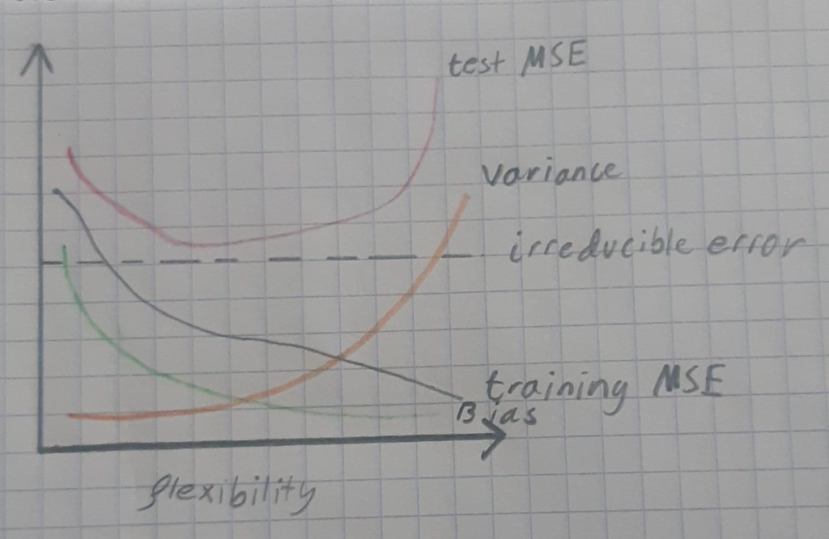

```r
knitr::include_graphics("plot.jpeg")
```

2. test MSE: As flexibility increase, test MSE initially decreases as the increased flexibility better fits the true relationship of the data. However, as it increases further, test MSE will plateau and increase as the method begins to overfit the training data.

training MSE: Training MSE monotonically decreases with increasing flexibility as the methods gradually fit the training data better (and overfit it).

Irreducible error: This error is constant as it is a result of the predictors that we have not measured but contribute to the response.

Variance: This monotonically increases with flexibility as the overfitting of the training data prevents the model from reliably predicting response in test data.

Bias: This monotonically decreases as flexibility increases as the method is more capable of fitting the training data.

#4)

1. 1 - Cell type classification: the response here is the cell type and the predictors are gene expression. Generally, the goal is prediction (although inference would the goal when trying to understand what genes lead to a cell type) as we want to use the measured gene expression to know what cell type the cell belongs to. 2 - Animal classification: the response is the animal and the predictors are physical traits (i.e. fur,number of legs,scales, horns etc.). The goal here is prediction as we want to identify what the animal is. 3 - Identifying students that will be hired after graduation: the response is whether the student was hired and the predictors are metrics related to academics and extracurricular activities. This would be an inference problem asked by an academic institution to know what factors contribute to a student’s ability to be hired. With this, the institution could infer what aspects of their programs to develop to increase the success rate of their alumni.
2. 1- Lemonade stand sales: response is the total sales in one day and predictors are weather, temperature and season. This could be an inference problem to know how each predictor affects the response, and therefore know what the ideal conditions are for optimal sales. Alternatively, this could be a prediction problem to anticipate how many sales will be made in the future, and therefore know how much produce to buy beforehand to reach it. 2- Amount of snowfall: response is snowfall in centimeters and predictors are temperature, humidity, and number of consecutive snowless days. This is a prediction problem as we want to know how much snow will fall in the future. 3- Estimated traffic time: response is traffic time and predictors are time of day, day of the week and season. This is a prediction problem as we want to know how much time we are expected to be in traffic in the future. This could be an inference problem if we are interested in knowing what predictors contribute most to traffic time and therefore which ones to use to avoid traffic.
3. 1- Genetic study of disease: enables us to determine if the gene expression of individuals is distinct based on the presence of absence of a disease. 2- Political campaign: Can use surveys to determine if different demographics have distinct issues that they prioritize. 3- Ad recommendations: Identify demographics that like/buy similar products and share ads that other people in the same cluster have clicked on.

#5)

A very flexible approach helps ensure our model better fits the relationship found in the data. This can lead to a more accurate prediction than a less flexible method. These methods are also much better at reducing bias. However, more flexible methods are also more likely to overfit the data by misinterpreting noise as part of the relationship whereas less flexible methods do not have this issue. A more flexible approach may be more desirable in cases where our goal is simply prediction and/or the data does not seem to have a truly linear relationship. A less flexible approach is more desirable when the goal is inference as it makes the model more interpretable. It may also be valuable in training sets with low sample numbers as it is less likely to overfit.

#6) Parametric approaches focus on reducing the prediction of a response to measuring a set of predictors and applying them to a function f(x). Non-parametric approaches do not make any assumptions about the actual form of f(x). The advantage of parametric approaches is that it needs a lot less observations to generate an accurate model of f than non-parametric methods as it reduces f(x) to a selection of predictors. However, the disadvantage of parametric methods is that they assume that f(x) has a particular form, which will not exactly match the true f meaning our model could have a very large bias if the wrong assumption is made.

#7)

1. Obs. X1 X2 X3 Distance Y ——————————————— 1 0 3 0 3 Red 2 2 0 0 2 Red 3 0 1 3 sqrt(10) Red 4 0 1 2 sqrt(5) Green 5 -1 0 1 sqrt(2) Green 6 1 1 1 sqrt(3) Red
2. Green - nearest observation is observation 5 with a euclidean distance of sqrt(2). As this observation is Green, so is our test point
3. Red - two of the three nearest observations are classed as Red. Therefore, so is the test point.
4. As K is inversely proportional to flexibility and non-linear relationships are better estimated by flexible methods, this model would need a low K to retain accuracy.

## Applied

#8)

```r
college <- read.csv("../datasets/College.csv")
rownames(college) <- college[,1]
college <- college[,-1]
college[,1] <- as.factor(college[,1])
# For Private Column: private -> 2, public -> 1
head(college)
```

|  | Private | Apps | Accept | Enroll | Top10perc | Top25perc | F.Undergrad | P.Undergrad | Outstate | Room.Board | Books | Personal | PhD | Terminal | S.F.Ratio | perc.alumni | Expend | Grad.Rate |
| --- | --- | --- | --- | --- | --- | --- | --- | --- | --- | --- | --- | --- | --- | --- | --- | --- | --- | --- |
| Abilene Christian University | Yes | 1660 | 1232 | 721 | 23 | 52 | 2885 | 537 | 7440 | 3300 | 450 | 2200 | 70 | 78 | 18.1 | 12 | 7041 | 60 |
| Adelphi University | Yes | 2186 | 1924 | 512 | 16 | 29 | 2683 | 1227 | 12280 | 6450 | 750 | 1500 | 29 | 30 | 12.2 | 16 | 10527 | 56 |
| Adrian College | Yes | 1428 | 1097 | 336 | 22 | 50 | 1036 | 99 | 11250 | 3750 | 400 | 1165 | 53 | 66 | 12.9 | 30 | 8735 | 54 |
| Agnes Scott College | Yes | 417 | 349 | 137 | 60 | 89 | 510 | 63 | 12960 | 5450 | 450 | 875 | 92 | 97 | 7.7 | 37 | 19016 | 59 |
| Alaska Pacific University | Yes | 193 | 146 | 55 | 16 | 44 | 249 | 869 | 7560 | 4120 | 800 | 1500 | 76 | 72 | 11.9 | 2 | 10922 | 15 |
| Albertson College | Yes | 587 | 479 | 158 | 38 | 62 | 678 | 41 | 13500 | 3335 | 500 | 675 | 67 | 73 | 9.4 | 11 | 9727 | 55 |

```r
summary(college)
```

```
 Private        Apps           Accept          Enroll       Top10perc       Top25perc      F.Undergrad     P.Undergrad         Outstate       Room.Board
 No :212   Min.   :   81   Min.   :   72   Min.   :  35   Min.   : 1.00   Min.   :  9.0   Min.   :  139   Min.   :    1.0   Min.   : 2340   Min.   :1780
 Yes:565   1st Qu.:  776   1st Qu.:  604   1st Qu.: 242   1st Qu.:15.00   1st Qu.: 41.0   1st Qu.:  992   1st Qu.:   95.0   1st Qu.: 7320   1st Qu.:3597
           Median : 1558   Median : 1110   Median : 434   Median :23.00   Median : 54.0   Median : 1707   Median :  353.0   Median : 9990   Median :4200
           Mean   : 3002   Mean   : 2019   Mean   : 780   Mean   :27.56   Mean   : 55.8   Mean   : 3700   Mean   :  855.3   Mean   :10441   Mean   :4358
           3rd Qu.: 3624   3rd Qu.: 2424   3rd Qu.: 902   3rd Qu.:35.00   3rd Qu.: 69.0   3rd Qu.: 4005   3rd Qu.:  967.0   3rd Qu.:12925   3rd Qu.:5050
           Max.   :48094   Max.   :26330   Max.   :6392   Max.   :96.00   Max.   :100.0   Max.   :31643   Max.   :21836.0   Max.   :21700   Max.   :8124
     Books           Personal         PhD            Terminal       S.F.Ratio      perc.alumni        Expend        Grad.Rate
 Min.   :  96.0   Min.   : 250   Min.   :  8.00   Min.   : 24.0   Min.   : 2.50   Min.   : 0.00   Min.   : 3186   Min.   : 10.00
 1st Qu.: 470.0   1st Qu.: 850   1st Qu.: 62.00   1st Qu.: 71.0   1st Qu.:11.50   1st Qu.:13.00   1st Qu.: 6751   1st Qu.: 53.00
 Median : 500.0   Median :1200   Median : 75.00   Median : 82.0   Median :13.60   Median :21.00   Median : 8377   Median : 65.00
 Mean   : 549.4   Mean   :1341   Mean   : 72.66   Mean   : 79.7   Mean   :14.09   Mean   :22.74   Mean   : 9660   Mean   : 65.46
 3rd Qu.: 600.0   3rd Qu.:1700   3rd Qu.: 85.00   3rd Qu.: 92.0   3rd Qu.:16.50   3rd Qu.:31.00   3rd Qu.:10830   3rd Qu.: 78.00
 Max.   :2340.0   Max.   :6800   Max.   :103.00   Max.   :100.0   Max.   :39.80   Max.   :64.00   Max.   :56233   Max.   :118.00
```

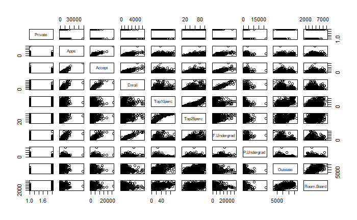

```r
#Scatterplot matrix of the first ten variables
tmp <- college
tmp[,1] <- as.numeric(college[,1])
pairs(tmp[,1:10])
```

```r
#Private vs. Out-of-state tuition boxplot
plot( x = college$Private, y = college$Outstate,xlab = "Private Institution", ylab = "Out-of-State Tuition (USD)", main = "Out-of-State Tuition Boxplot")

college$Elite <- as.factor(ifelse(college$Top10perc > 50, "Yes", "No"))
summary(college)
```

```
 Private        Apps           Accept          Enroll       Top10perc       Top25perc      F.Undergrad     P.Undergrad         Outstate       Room.Board
 No :212   Min.   :   81   Min.   :   72   Min.   :  35   Min.   : 1.00   Min.   :  9.0   Min.   :  139   Min.   :    1.0   Min.   : 2340   Min.   :1780
 Yes:565   1st Qu.:  776   1st Qu.:  604   1st Qu.: 242   1st Qu.:15.00   1st Qu.: 41.0   1st Qu.:  992   1st Qu.:   95.0   1st Qu.: 7320   1st Qu.:3597
           Median : 1558   Median : 1110   Median : 434   Median :23.00   Median : 54.0   Median : 1707   Median :  353.0   Median : 9990   Median :4200
           Mean   : 3002   Mean   : 2019   Mean   : 780   Mean   :27.56   Mean   : 55.8   Mean   : 3700   Mean   :  855.3   Mean   :10441   Mean   :4358
           3rd Qu.: 3624   3rd Qu.: 2424   3rd Qu.: 902   3rd Qu.:35.00   3rd Qu.: 69.0   3rd Qu.: 4005   3rd Qu.:  967.0   3rd Qu.:12925   3rd Qu.:5050
           Max.   :48094   Max.   :26330   Max.   :6392   Max.   :96.00   Max.   :100.0   Max.   :31643   Max.   :21836.0   Max.   :21700   Max.   :8124
     Books           Personal         PhD            Terminal       S.F.Ratio      perc.alumni        Expend        Grad.Rate      Elite
 Min.   :  96.0   Min.   : 250   Min.   :  8.00   Min.   : 24.0   Min.   : 2.50   Min.   : 0.00   Min.   : 3186   Min.   : 10.00   No :699
 1st Qu.: 470.0   1st Qu.: 850   1st Qu.: 62.00   1st Qu.: 71.0   1st Qu.:11.50   1st Qu.:13.00   1st Qu.: 6751   1st Qu.: 53.00   Yes: 78
 Median : 500.0   Median :1200   Median : 75.00   Median : 82.0   Median :13.60   Median :21.00   Median : 8377   Median : 65.00
 Mean   : 549.4   Mean   :1341   Mean   : 72.66   Mean   : 79.7   Mean   :14.09   Mean   :22.74   Mean   : 9660   Mean   : 65.46
 3rd Qu.: 600.0   3rd Qu.:1700   3rd Qu.: 85.00   3rd Qu.: 92.0   3rd Qu.:16.50   3rd Qu.:31.00   3rd Qu.:10830   3rd Qu.: 78.00
 Max.   :2340.0   Max.   :6800   Max.   :103.00   Max.   :100.0   Max.   :39.80   Max.   :64.00   Max.   :56233   Max.   :118.00
```

[figure not shown]

```r
#Histograms
par(mfrow= c(2,2))
```

```r
hist(college$Apps,col = 2, ylab = "Counts", xlab = "Number of Applicants" )
hist(college$PhD, col = 3, ylab = "Counts", xlab = "% of Faculty with PhDs" )
```

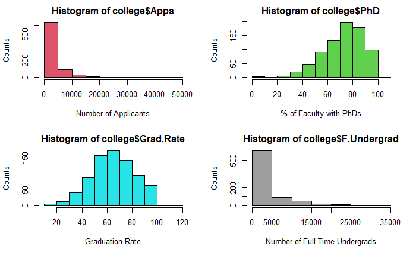

```r
hist(college$Grad.Rate, col = 5, ylab = "Counts", xlab = "Graduation Rate" )
hist(college$F.Undergrad, col = 8, ylab = "Counts", xlab = "Number of Full-Time Undergrads" )
```

```r
##Observations
#skewed distribution of PhD holders in faculty positions
#Normal distribution for graduation rates
#Reviewing summary statistics shows anomalies in Graduation rate and PhD variables where there are values above 100%
unique(c(rownames(college)[college$PhD > 100],rownames(college)[college$Grad.Rate > 100]))
```

```
[1] "Texas A&M University at Galveston" "Cazenovia College"
```

```r
#The two erroneous values concern Texas A&M and Cazenovia College
```

#9)

```r
car <- read.csv("../datasets/Auto.csv")
car[car == "?"] <- NA
car <- na.omit(car)
head(car)
```

|  | mpg | cylinders | displacement | horsepower | weight | acceleration | year | origin | name |
| --- | --- | --- | --- | --- | --- | --- | --- | --- | --- |
| 1 | 18 | 8 | 307 | 130 | 3504 | 12.0 | 70 | 1 | chevrolet chevelle malibu |
| 2 | 15 | 8 | 350 | 165 | 3693 | 11.5 | 70 | 1 | buick skylark 320 |
| 3 | 18 | 8 | 318 | 150 | 3436 | 11.0 | 70 | 1 | plymouth satellite |
| 4 | 16 | 8 | 304 | 150 | 3433 | 12.0 | 70 | 1 | amc rebel sst |
| 5 | 17 | 8 | 302 | 140 | 3449 | 10.5 | 70 | 1 | ford torino |
| 6 | 15 | 8 | 429 | 198 | 4341 | 10.0 | 70 | 1 | ford galaxie 500 |

```r
#mpg, cylinders, displacement,weight, horsepower and acceleration are quantitative traits whereas year, origin and name are categorical

dim(car)
```

```
[1] 392   9
```

```r
sapply(car[,c(1:3,5,6)],range)
```

```
      mpg cylinders displacement weight acceleration
[1,]  9.0         3           68   1613          8.0
[2,] 46.6         8          455   5140         24.8
```

```r
sapply(car[,c(1:3,5,6)],mean)
```

```
         mpg    cylinders displacement       weight acceleration
   23.445918     5.471939   194.411990  2977.584184    15.541327
```

```r
sapply(car[,c(1:3,5,6)],sd)
```

```
         mpg    cylinders displacement       weight acceleration
    7.805007     1.705783   104.644004   849.402560     2.758864
```

```r
subset_car <- car[-c(10:85),c(1:3,5,6)]
sapply(subset_car,range)
```

```
      mpg cylinders displacement weight acceleration
[1,] 11.0         3           68   1649          8.5
[2,] 46.6         8          455   4997         24.8
```

```r
sapply(subset_car,mean)
```

```
         mpg    cylinders displacement       weight acceleration
   24.404430     5.373418   187.240506  2935.971519    15.726899
```

```r
sapply(subset_car,sd)
```

```
         mpg    cylinders displacement       weight acceleration
    7.867283     1.654179    99.678367   811.300208     2.693721
```

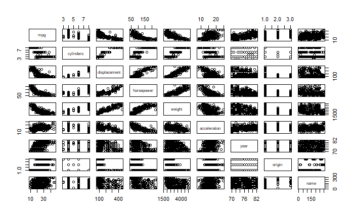

```r
#Exploration
car$horsepower <- as.numeric(car$horsepower)
car$name <- as.factor(car$name)
pairs(car)
```

```r
##Observations
# The categorical traits show little correlation with the quantitative traits
#Many of the correlations between the quantitative traits show linear trends when displacement, horsepower, or weight are one or both of the variables
#Based of the scatterplots, displacement, horsepower and weight may be the best predictors for mpg as they display linear correlations with mpg.
```

#10)

```r
library(MASS)
dim(Boston)
```

```
[1] 506  14
```

```r
#Dataset contains 506 rows and 14 observations
head(Boston)
```

|  | crim | zn | indus | chas | nox | rm | age | dis | rad | tax | ptratio | black | lstat | medv |
| --- | --- | --- | --- | --- | --- | --- | --- | --- | --- | --- | --- | --- | --- | --- |
| 1 | 0.00632 | 18 | 2.31 | 0 | 0.538 | 6.575 | 65.2 | 4.0900 | 1 | 296 | 15.3 | 396.90 | 4.98 | 24.0 |
| 2 | 0.02731 | 0 | 7.07 | 0 | 0.469 | 6.421 | 78.9 | 4.9671 | 2 | 242 | 17.8 | 396.90 | 9.14 | 21.6 |
| 3 | 0.02729 | 0 | 7.07 | 0 | 0.469 | 7.185 | 61.1 | 4.9671 | 2 | 242 | 17.8 | 392.83 | 4.03 | 34.7 |
| 4 | 0.03237 | 0 | 2.18 | 0 | 0.458 | 6.998 | 45.8 | 6.0622 | 3 | 222 | 18.7 | 394.63 | 2.94 | 33.4 |
| 5 | 0.06905 | 0 | 2.18 | 0 | 0.458 | 7.147 | 54.2 | 6.0622 | 3 | 222 | 18.7 | 396.90 | 5.33 | 36.2 |
| 6 | 0.02985 | 0 | 2.18 | 0 | 0.458 | 6.430 | 58.7 | 6.0622 | 3 | 222 | 18.7 | 394.12 | 5.21 | 28.7 |

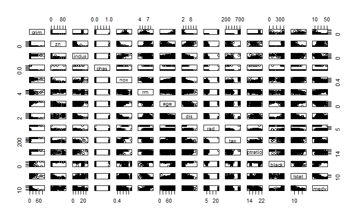

```r
pairs(Boston)
```

```r
nrow(Boston[Boston$chas == 1,])
```

```
[1] 35
```

```r
median(Boston$ptratio)
```

```
[1] 19.05
```

```r
rownames(Boston[Boston$medv == min(Boston$medv),])
```

```
[1] "399" "406"
```

```r
nrow(Boston[Boston$rm > 7,])
```

```
[1] 64
```

```r
nrow(Boston[Boston$rm > 8,])
```

```
[1] 13
```

```r
summary(Boston[Boston$rm > 8,])
```

```
      crim               zn            indus             chas             nox               rm             age             dis             rad
 Min.   :0.02009   Min.   : 0.00   Min.   : 2.680   Min.   :0.0000   Min.   :0.4161   Min.   :8.034   Min.   : 8.40   Min.   :1.801   Min.   : 2.000
 1st Qu.:0.33147   1st Qu.: 0.00   1st Qu.: 3.970   1st Qu.:0.0000   1st Qu.:0.5040   1st Qu.:8.247   1st Qu.:70.40   1st Qu.:2.288   1st Qu.: 5.000
 Median :0.52014   Median : 0.00   Median : 6.200   Median :0.0000   Median :0.5070   Median :8.297   Median :78.30   Median :2.894   Median : 7.000
 Mean   :0.71879   Mean   :13.62   Mean   : 7.078   Mean   :0.1538   Mean   :0.5392   Mean   :8.349   Mean   :71.54   Mean   :3.430   Mean   : 7.462
 3rd Qu.:0.57834   3rd Qu.:20.00   3rd Qu.: 6.200   3rd Qu.:0.0000   3rd Qu.:0.6050   3rd Qu.:8.398   3rd Qu.:86.50   3rd Qu.:3.652   3rd Qu.: 8.000
 Max.   :3.47428   Max.   :95.00   Max.   :19.580   Max.   :1.0000   Max.   :0.7180   Max.   :8.780   Max.   :93.90   Max.   :8.907   Max.   :24.000
      tax           ptratio          black           lstat           medv
 Min.   :224.0   Min.   :13.00   Min.   :354.6   Min.   :2.47   Min.   :21.9
 1st Qu.:264.0   1st Qu.:14.70   1st Qu.:384.5   1st Qu.:3.32   1st Qu.:41.7
 Median :307.0   Median :17.40   Median :386.9   Median :4.14   Median :48.3
 Mean   :325.1   Mean   :16.36   Mean   :385.2   Mean   :4.31   Mean   :44.2
 3rd Qu.:307.0   3rd Qu.:17.40   3rd Qu.:389.7   3rd Qu.:5.12   3rd Qu.:50.0
 Max.   :666.0   Max.   :20.20   Max.   :396.9   Max.   :7.44   Max.   :50.0
```

```r
#Suburbs with more than 8 rooms per dwelling have a very low crime rate, and a lower ptratio and lstat
#The medv is also double that of the entire city
```